# Homework Two Solutions

Biostatistics 735 — Machine Learning in Public Health

Published

September 25, 2026

Setup and packages used.

```r
library(formatR)
library(kableExtra)
library(tidyverse)
library(rsample)
library(recipes)
library(yardstick)
library(caret)
library(MASS)      # birthweight data
library(broom)     # augment for residuals, leverage, cooks distance
library(lmtest)    # bptest for heteroscedasticity
library(car)       # vif, component+residual plots
library(glmnet)   # ridge/lasso
library(lars)     # diabetes data (public health: diabetes progression)
library(ncvreg)   # MCP/SCAD
library(mlbench)
```

# 1 Question 1

Below is the code contained in the question:

```r
# Load and prepare data
data("birthwt", package = "MASS")
# Remove "low" variable.
bw <- birthwt[,-1]

# Create factors where appropriate
bw$race <- factor(bw$race, labels = c("white","black","other"))
bw$smoke <- factor(bw$smoke, labels = c("nonsmoker","smoker"))
bw$ht    <- factor(bw$ht, labels = c("no","yes"))
bw$ui    <- factor(bw$ui, labels = c("no","yes"))

# Define outcome and predictors
outcome <- "bwt"
predictors <- setdiff(names(bw), outcome)

# Generate all subsets up to size 4 (to keep it manageable)
subsets <- unlist(
  lapply(1:4, function(k) combn(predictors, k, simplify = FALSE)),
  recursive = FALSE
)

# Create formulas
formulas <- lapply(subsets, function(vars) {
  as.formula(paste(outcome, "~", paste(vars, collapse = " + ")))
})
```

## 1.1 Part A

(**10 points**) Fit a standard multiple linear regression with **birth weight** as the outcome. Use adjusted $R^2$, BIC, and Mallows Cp to explore which predictors are important.

**Answer** you actually don’t need to use the code above to answer this question. As we say “there is more than one way to kill a rat.” However, I’ll show both versions.

**Using the code above**

```r
# Fit each model and compute Adjusted R^2, BIC, and Mallows Cp
get_fit_stats <- function(form, data, sigma2_full) {
  fit <- lm(form, data = data)

  # Calculate Mallows Cp
  n <- nobs(fit)                     # sample size
  p <- length(coef(fit))             # number of parameters incl intercept
  sse <- deviance(fit)               # residual sum of squares

  cp <- sse/sigma2_full - (n - 2*p)

  tibble(
    model = deparse(form),
    n_params = p,
    sse = sse,
    adj_r2 = summary(fit)$adj.r.squared,
    bic = BIC(fit),
    cp = cp
  )
}

# Get all fit statistics, then keep only the best model (best sse) for each value of p
# For Mallows get the MSE from the full model
fit_full <- lm(bwt ~ ., data = bw)
sigma2_full <- summary(fit_full)$sigma^2  #

rmse_df <- purrr::map_dfr(formulas, get_fit_stats, data = bw, sigma2_full = sigma2_full)  %>%
  group_by(n_params) %>%
  arrange(sse) %>%
  filter(row_number() == 1)

rmse_df  %>% knitr::kable(digits = 3)
```

| model | n_params | sse | adj_r2 | bic | cp |
| --- | --- | --- | --- | --- | --- |
| bwt ~ race + smoke + ht + ui | 6 | 78611734 | 0.192 | 3018.387 | 8.879 |
| bwt ~ race + smoke + ui | 5 | 81069681 | 0.171 | 3018.964 | 12.691 |
| bwt ~ lwt + ht + ui | 4 | 85191369 | 0.134 | 3023.095 | 20.437 |
| bwt ~ ht + ui | 3 | 88748030 | 0.103 | 3025.583 | 26.847 |
| bwt ~ ui | 2 | 91910625 | 0.076 | 3026.960 | 32.325 |

All model fit criteria like the model with all 4 predictors. Here’s the coefficients for the best 4 predictor model:

```r
best_model <- lm(rmse_df$model[1], data = bw)
coef(best_model, id = 4)  %>% knitr::kable(digits = 3)
```

|  | x |
| --- | --- |
| (Intercept) | 3412.764 |
| raceblack | -425.061 |
| raceother | -409.259 |
| smokesmoker | -386.203 |
| htyes | -472.328 |
| uiyes | -563.088 |

**Not using the code above** (which is much simplier).

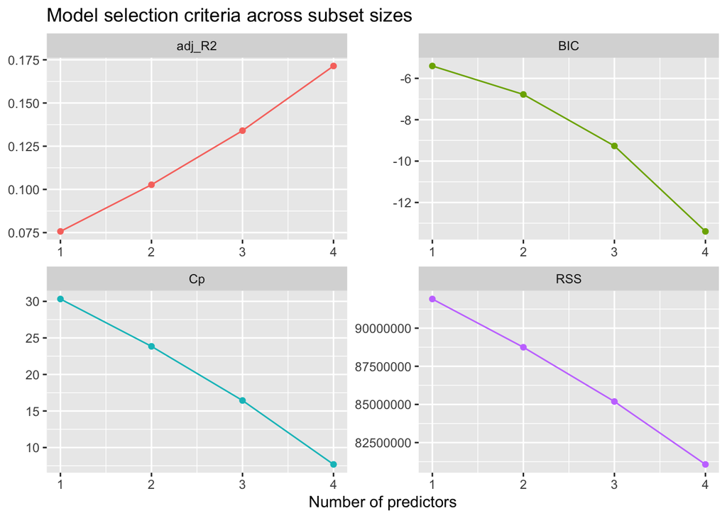

```r
library(leaps)
best_subset <- regsubsets(bwt ~ ., bw, nvmax = 4) #only up to 4 since that's what above uses
results <- summary(best_subset)

summ_results <- tibble(
  predictors = 1:4,
  adj_R2 = results$adjr2,
  Cp     = abs(results$cp - 2:5), # Want Cp to be close to p+1
  BIC    = results$bic,
  RSS    = results$rss
)

summ_results %>%
  pivot_longer(-predictors, names_to = "stat", values_to = "value") %>%
  ggplot(aes(predictors, value, color = stat)) +
  geom_line(show.legend = FALSE) +
  geom_point(show.legend = FALSE) +
  facet_wrap(~ stat, scales = "free") +
  labs(x = "Number of predictors", y = NULL,
       title = "Model selection criteria across subset sizes")
```

All model fit criteria like the model with all 4 predictors. Here’s the predictors in the best 4 predictor model:

```r
coef(best_subset, id = 4)  %>% knitr::kable(digits = 3)
```

|  | x |
| --- | --- |
| (Intercept) | 3387.351 |
| raceblack | -455.406 |
| raceother | -417.073 |
| smokesmoker | -393.561 |
| uiyes | -527.659 |

**Note:** notice that the answers are not the same! The easier version treats `raceblack` and `raceother` as two separate predictors. Technically, this is correct as the race variable creates two dummy variables. However, I think in practice we would consider `race` to be a single predictor variable (even with dummy coding).

## 1.2 Part B

(**5 points**) Use backwards selection criteria to find the best model.

```r
bf_mod  <- lm(bwt ~ ., data = bw)
back_mf <- stepAIC(bf_mod, direction = "backward", trace = FALSE)

back_mf$coefficients  %>% knitr::kable(digits = 3)
```

|  | x |
| --- | --- |
| (Intercept) | 2837.264 |
| lwt | 4.242 |
| raceblack | -475.058 |
| raceother | -348.150 |
| smokesmoker | -356.321 |
| htyes | -585.193 |
| uiyes | -525.524 |

## 1.3 Part C

(**5 points**) Fit a **forward stagewise regression** model on the same data.

**Answer** the code for this is similar to what we used in class. However, first we need to create a design matrix from our predictor variables since the `lars` functions don’t work with factors.

```r
# Create design matrix for X
X_only <- bw[,colnames(bw) != "bwt"]
# Get formula for all X variables
X_form <- as.formula(paste("~", paste(colnames(X_only), collapse = " + ")))
X_form
```

```
~age + lwt + race + smoke + ptl + ht + ui + ftv
```

```r
# Get design matrix for formula (the [,-1] will remove the intercept)
X <- model.matrix(X_form, data = bw)[,-1]
head(X, 3)  %>% knitr::kable(digits = 3)
```

|  | age | lwt | raceblack | raceother | smokesmoker | ptl | htyes | uiyes | ftv |
| --- | --- | --- | --- | --- | --- | --- | --- | --- | --- |
| 85 | 19 | 182 | 1 | 0 | 0 | 0 | 0 | 1 | 0 |
| 86 | 33 | 155 | 0 | 1 | 0 | 0 | 0 | 0 | 3 |
| 87 | 20 | 105 | 0 | 0 | 1 | 0 | 0 | 0 | 1 |

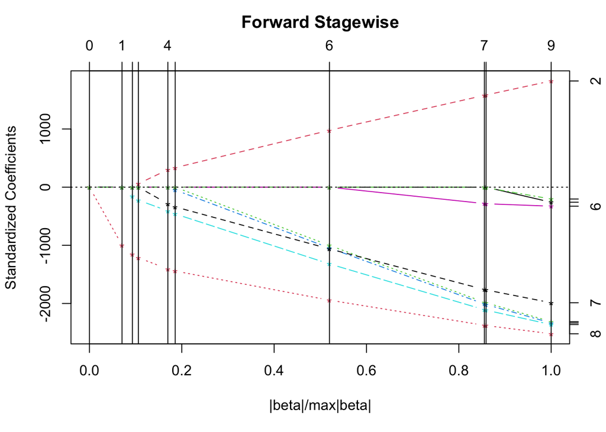

```r
y <- bw$bwt

# 1) Fit the full forward stagewise model
ForStag_mf <- lars(X, y,
                   type = "forward.stagewise", trace = FALSE)
plot(ForStag_mf)
```

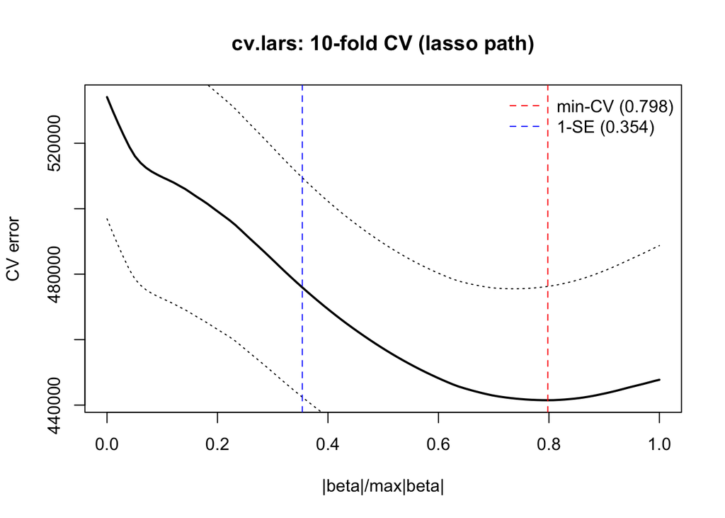

```r
# 2) K-fold CV along that path (K = 10 here)
set.seed(735794)
cv_out <- cv.lars(X, y, K = 10, type = "forward.stagewise", plot.it = FALSE, se = TRUE)

# The CV object contains:
# cv_out$cv        -> mean CV error at each fraction
# cv_out$cv.error  -> (approx) SE of CV error at each fraction
# cv_out$index     -> Abscissa values at which the CV curve is be computed.
#                     If mode="fraction" this is the fraction of the saturated |beta|.

# 3) Pick tuning by minimum CV
i_min <- which.min(cv_out$cv)
frac_min <- cv_out$index[i_min]

# 1-SE rule: pick the simplest (largest shrinkage / smaller fraction)
# whose CV error <= cv_min + SE_min.
cv_min <- cv_out$cv[i_min]
se_min <- cv_out$cv.error[i_min]
target <- cv_min + se_min

# Among all fractions with CV <= target, pick the *smallest* index that
# still satisfies this (for lars' fraction scale, smaller fraction = less variables in the model).
i_1se <- min(which(cv_out$cv <= target))
frac_1se <- cv_out$index[i_1se]

# 4) Inspect / plot the CV curve
plot(cv_out$index, cv_out$cv, type = "l", lwd = 2,
     xlab = "|beta|/max|beta|", ylab = "CV error",
     main = "cv.lars: 10-fold CV (lasso path)")
lines(cv_out$index, cv_out$cv + cv_out$cv.error, lty = 3)
lines(cv_out$index, cv_out$cv - cv_out$cv.error, lty = 3)
abline(v = c(frac_min, frac_1se), col = c("red","blue"), lty = 2)
legend("topright",
       c(sprintf("min-CV (%.3f)", frac_min),
         sprintf("1-SE (%.3f)", frac_1se)),
       col = c("red","blue"), lty = 2, bty = "n")
```

```r
# 5) Coefficients at chosen fraction (min-CV shown; use frac_1se similarly)
coef_min <- predict(ForStag_mf, s = frac_min, type = "coef", mode = "fraction")$coefficients
coef_min  %>% knitr::kable(digits = 3)
```

|  | x |
| --- | --- |
| age | 0.000 |
| lwt | 3.518 |
| raceblack | -382.488 |
| raceother | -280.381 |
| smokesmoker | -294.022 |
| ptl | -34.613 |
| htyes | -489.366 |
| uiyes | -471.197 |
| ftv | 0.000 |

```r
coef_1se <- predict(ForStag_mf, s = frac_1se, type = "coef", mode = "fraction")$coefficients
coef_1se  %>% knitr::kable(digits = 3)
```

|  | x |
| --- | --- |
| age | 0.000 |
| lwt | 1.568 |
| raceblack | -106.198 |
| raceother | -83.532 |
| smokesmoker | -132.919 |
| ptl | 0.000 |
| htyes | -209.385 |
| uiyes | -346.792 |
| ftv | 0.000 |

The 1se model is similar to the previous models we’ve found in terms of varibles in the model. It has the same variables as the backwards model, but different coefficient estimates. The “min” model includes more variables than any of the models we’ve used before.

## 1.4 Part D

**Answer:** To implement this we are going to alter the code from class to use MAD instead of RMSE to select the best model.

Previously, we used the `yardstick` package to estimate the rmse via the `rmse_vec` function. `yardstick` has a mean absolute error (`mae`) function, but not an MAD function. So, we’ll create one.

```r
library(rsample)    # splitting, vfolds

#Create function to calculate mad
mad_vec <- function(obs,pred){
  median(abs(obs - pred))
}

# Function to implement the CV
cv_fit <- function(form_str, folds){
  form <- as.formula(form_str)
  # compute MAD across folds
  mad_vals <- map_dbl(folds$splits, function(s){
    tr <- analysis(s); va <- assessment(s)
    fit <- lm(form, data = tr)
    pred <- predict(fit, newdata = va)
    mad_vec(va$bwt, pred)
  })
  tibble(
    model = Reduce(paste, deparse(form)),
    cv_mad = mean(mad_vals),
    cv_sd = sd(mad_vals)
  )
}

# Implement the CV
set.seed(2024)
folds <- vfold_cv(bw, v = 10)

cv_res <- formulas %>%  purrr::map_dfr(cv_fit, folds = folds) %>%
  arrange(cv_mad)

cv_res %>% slice_head(n = 10) %>% knitr::kable(digits = 3, caption = "Top 10 candidates by 10-fold CV (training set only)")
```

Top 10 candidates by 10-fold CV (training set only)

| model | cv_mad | cv_sd |
| --- | --- | --- |
| bwt ~ race + smoke + ht + ui | 455.528 | 124.354 |
| bwt ~ lwt + race + smoke + ui | 465.983 | 108.302 |
| bwt ~ age + race + smoke + ui | 470.041 | 108.493 |
| bwt ~ race + smoke + ui | 474.467 | 112.573 |
| bwt ~ age + lwt + smoke + ui | 475.971 | 92.791 |
| bwt ~ race + smoke + ht + ftv | 477.691 | 132.448 |
| bwt ~ age + smoke + ht + ui | 480.736 | 155.073 |
| bwt ~ lwt + smoke + ui | 482.588 | 90.862 |
| bwt ~ race + smoke + ui + ftv | 482.692 | 112.480 |
| bwt ~ race + smoke + ht | 482.776 | 129.920 |

## 1.5 Part E

(**10 points**) Perform either:

- **Nested CV**, or
- **CV with a separate test set**

to both select the best model *and* to estimate its prediction error (still using MAD).

**Answer:** I’ll show both options here.

For the nested CV, we can alter the code used in class similarly to how we did this in d.

```r
set.seed(2025)
outer_folds <- vfold_cv(bw, v = 10)

nested_scores <- map_dbl(outer_folds$splits, function(outer_split){

  tr_outer <- analysis(outer_split)
  te_outer <- assessment(outer_split)

  # inner CV on the outer training split
  inner_folds <- vfold_cv(tr_outer, v = 10)

  # run inner CV across the same grid
  inner_cv_res <- formulas %>%  purrr::map_dfr(cv_fit, folds = inner_folds) %>%
    arrange(cv_mad)

  # choose best by inner CV
  best_form <- as.formula(inner_cv_res$model[1])

  # refit on tr_outer, evaluate on te_outer (outer hold-out)
  fit_outer <- lm(best_form, data = tr_outer)
  mad_vec(te_outer$bwt, predict(fit_outer, newdata = te_outer))
})

nested_cv_mad <- median(nested_scores)
```

Now we’ll use the other approach. This will use the code from d, but only evaluated on a training set.

```r
# Train/test split
set.seed(42)
split <- initial_split(bw, prop = 2/3, strata = NULL)
train <- training(split)
test  <- testing(split)

# Implement the CV on the train
set.seed(2024)
folds <- vfold_cv(train, v = 10)

cv_res_tr <- formulas %>%  purrr::map_dfr(cv_fit, folds = folds) %>%
  arrange(cv_mad) %>% slice_head(n = 1)

# Here's the best model:
cv_res_tr$model[1]
```

```
[1] "bwt ~ race + smoke + ht + ui"
```

```r
# Refit the best model to the whole training set.
best_form <- as.formula(cv_res_tr$model[1])
fit_best_tr <- lm(best_form, data = train)

# Predict for the test set and calculate the MAD
pred_test <- predict(fit_best_tr, newdata = test)
test_MAD <- mad_vec(test$bwt, pred_test)
```

Now, we’ll compare the estimated MAD from nested CV, a test set after CV, and the best MAD from CV.

```r
tibble(
  Estimate = c("Nested CV MAD", "MAD on test set after CV", "Winner's CV MAD (from d.)"),
  Value    = c(nested_cv_mad, test_MAD, cv_res$cv_mad[1])
) %>% knitr::kable(digits = 3)
```

| Estimate | Value |
| --- | --- |
| Nested CV MAD | 480.675 |
| MAD on test set after CV | 459.981 |
| Winner’s CV MAD (from d.) | 455.528 |

We’d expect the winner’s CV to be the most biased.

## 1.6 Part F

(**5 points**) Compare results across all approaches and write a short paragraph on which model you would choose and why.

Various answers accepted.

# 2 Question 2

## 2.1 Part A

(**5 points**) Fit a linear regression model predicting **Ozone** levels using predictors you think are appropriate (e.g., Solar, Wind, Temp, Month). You don’t need to perform any model selection; simply select a model that you think is appropriate and use it for the remainder of this question.

**Answer:** Obviously there are a lot of different options here, but I’ll use up to a third degree polynomial for all variables.

```r
data(airquality)
## Remove missing values
airquality_cc <- airquality[complete.cases(airquality),]

formula <- Ozone ~ poly(Solar.R,3) + poly(Wind,3) + poly(Temp,3) + poly(Month,3) + poly(Day,3)

fit_airqual <- lm(formula, data = airquality_cc)
```

## 2.2 Part B

(**15 points**) Check the key regression assumptions:

- Linearity (residual plots, component+residual plots),
- Homoscedasticity (residuals vs fitted, Breusch–Pagan test),
- Normality of residuals (QQ plot),
- Influence (Cook’s distance, leverage).

Here, I’m going to follow things close to the example in class.

We’ll use the `broom` package to get the augmented residual data for leverage, cooks distance, etc.

```r
aug <- augment(fit_airqual)
head(aug,3)
```

```
# A tibble: 3 × 13
  .rownames Ozone `poly(Solar.R, 3)`[,"1"]  [,"2"]  [,"3"] `poly(Wind, 3)`[,"1"]
  <chr>     <int>                    <dbl>   <dbl>   <dbl>                 <dbl>
1 1            41                  0.00544 -0.101  -0.0138               -0.0681
2 2            36                 -0.0699  -0.0848  0.131                -0.0520
3 3            12                 -0.0374  -0.108   0.0781                0.0713
# ℹ 10 more variables: `poly(Wind, 3)`[2:3] <dbl>, `poly(Temp, 3)` <poly[,3]>,
#   `poly(Month, 3)` <poly[,3]>, `poly(Day, 3)` <poly[,3]>, .fitted <dbl>,
#   .resid <dbl>, .hat <dbl>, .sigma <dbl>, .cooksd <dbl>, .std.resid <dbl>
```

### 2.2.1 1) Linearity: Component + Residual (Partial Residual) Plots

If relationships are strongly curved, consider transformations or adding terms (splines, polynomials).

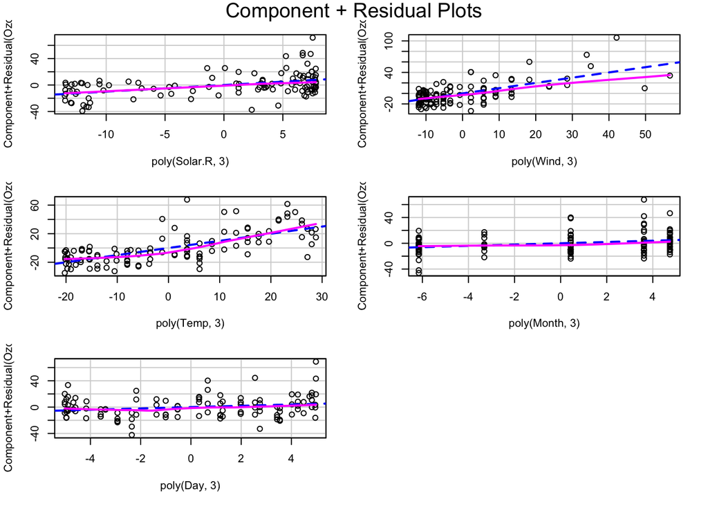

```r
car::crPlots(fit_airqual)  # opens a panel of C+R plots
```

I’ve already been pretty flexible in terms of how these variables can relate to the outcome, so it’s no surprise that all of these show relatively linear fits.

### 2.2.2 2) Normality of Residuals (Primarily for CIs/p-values)

For prediction, normality is less critical than calibration and unbiasedness, but we inspect QQ plot.

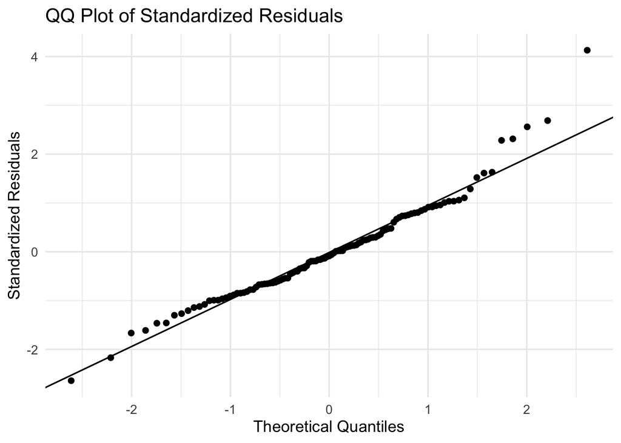

```r
ggplot(aug, aes(sample = .std.resid)) +
  stat_qq() + stat_qq_line() +
  labs(title = "QQ Plot of Standardized Residuals",
       x = "Theoretical Quantiles", y = "Standardized Residuals") +
  theme_minimal(base_size = 13)
```

There appears to be one outlier here (on the right side). Beside that, the normal assumption looks great.

### 2.2.3 3) Homoscedasticity (Constant Error Variance)

Look for funnel shapes; the red LOESS line should be roughly flat.

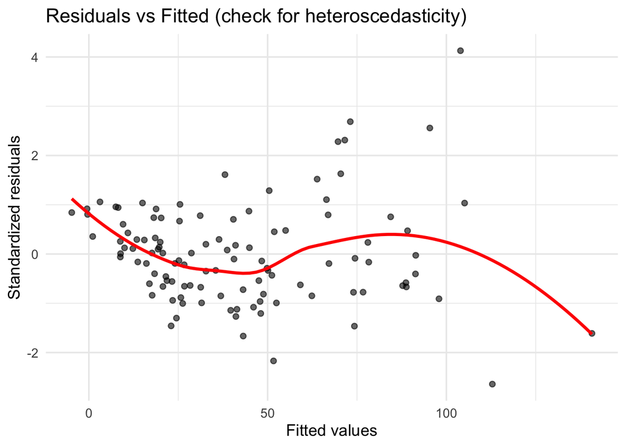

```r
ggplot(aug, aes(.fitted, .std.resid)) +
  geom_point(alpha = 0.6) +
  geom_smooth(se = FALSE, color = "red") +
  labs(x = "Fitted values", y = "Standardized residuals",
       title = "Residuals vs Fitted (check for heteroscedasticity)") +
  theme_minimal(base_size = 13)
```

Based on this plot, there is clear signs that the variance of the residuals is increasing with the mean. This is common in data that are bounded below by zero.

Let’s confirm with the Breusch-Pagan test:

```r
lmtest::bptest(fit_airqual)
```

```
    studentized Breusch-Pagan test

data:  fit_airqual
BP = 37.634, df = 15, p-value = 0.001022
```

I would (generally) refit the model using $\log(Ozone)$ instead of ozone.

### 2.2.4 4) Influence: Leverage & Cook’s Distance

Identify points that overly influence the fit.

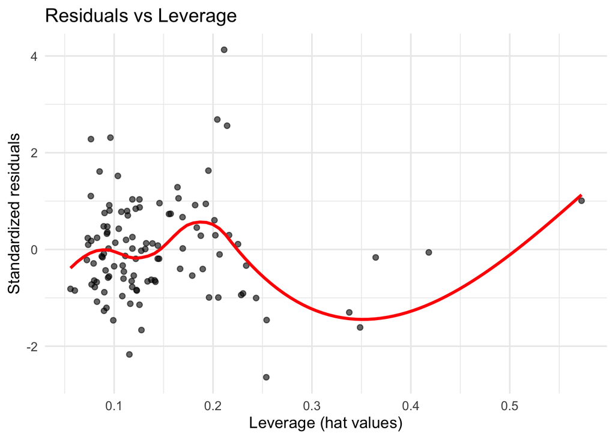

```r
ggplot(aug, aes(.hat, .std.resid)) +
  geom_point(alpha = 0.6) +
  geom_smooth(se = FALSE, color = "red") +
  labs(x = "Leverage (hat values)", y = "Standardized residuals",
       title = "Residuals vs Leverage") +
  theme_minimal(base_size = 13)
```

```r
# Top potentially influential points by Cook's D
aug %>%
  mutate(cook = .cooksd) %>%
  arrange(desc(cook)) %>%
  slice_head(n = 12) %>%
  dplyr::select(.fitted, .std.resid, .hat, cook) %>%
  knitr::kable(digits = 3, caption = "Top 10 observations by Cook's distance")
```

| .fitted | .std.resid | .hat | cook |
| --- | --- | --- | --- |
| 103.949 | 4.128 | 0.211 | 0.285 |
| 112.859 | -2.641 | 0.254 | 0.148 |
| 73.127 | 2.687 | 0.204 | 0.116 |
| 95.376 | 2.558 | 0.214 | 0.112 |
| 140.719 | -1.611 | 0.349 | 0.087 |
| 25.487 | 1.008 | 0.573 | 0.085 |
| 24.497 | -1.301 | 0.338 | 0.054 |
| 23.011 | -1.459 | 0.254 | 0.045 |
| 70.461 | 1.629 | 0.195 | 0.040 |
| 51.657 | -2.170 | 0.115 | 0.038 |
| 71.587 | 2.313 | 0.096 | 0.036 |
| 69.696 | 2.281 | 0.077 | 0.027 |

**Note:** the common cutoff for Cook’s D is $4/n$. I’m not sure where this cutoff came from, but in my experience this cutoff results in around 10% of the sample being labeled as an “outlier”. Here, $4/n = 0.036$ would result in $11$ outliers out of $111$.

What’s more important than the cufoff is to look at values that are far away from others. Let’s look at the data for the person with the largest Cook’s distance.

```r
aug%>%
  mutate(cook = .cooksd) %>%
  arrange(desc(cook)) %>%
  slice_head(n = 1) %>%
  dplyr::select(Ozone,.fitted:cook)
```

```
# A tibble: 1 × 8
  Ozone .fitted .resid  .hat .sigma .cooksd .std.resid  cook
  <int>   <dbl>  <dbl> <dbl>  <dbl>   <dbl>      <dbl> <dbl>
1   168    104.   64.1 0.211   15.9   0.285       4.13 0.285
```

```r
airquality %>%
  filter(Ozone == 168)
```

```
  Ozone Solar.R Wind Temp Month Day
1   168     238  3.4   81     8  25
```

This day has the highest ozone measurement. As I said above, I would transform the outcome (in real life), where this observation wouldn’t be an issue.

## 2.3 Part C

(**10 points**) Estimate the **prediction error (MAD)** of your model separately for each **Month**. Report MAD in May, June, July, August, and September. Comment on whether the model performs equally well across months, and what that might suggest about seasonal variation.

**Answer:** When we have data that have a temporal structure we should respect that structure when doing cross-validation. That is, the error for August, for example, should not be obtained from a model that contains September. As a result, to get the error for August, we should only use the data from May through July.

As a result, I’m going to do this the *right* way but only for June through September. For this model, I’m only going to use a linear effect of `Month` since the 3rd degree polynomial will only work when I have 3 different months. When only May is in the training set, I can’t have any effect of Month.

```r
MAD_error_seq <- function(mon){

  # Setting the model formula separately for June versus the others.
  if(mon == 6){
    formula <- Ozone ~ poly(Solar.R,3) + poly(Wind,3) + poly(Temp,3) + poly(Day,3)
  }else{
    formula <- Ozone ~ poly(Solar.R,3) + poly(Wind,3) + poly(Temp,3) + Month + poly(Day,3)
  }
  tr <- airquality_cc %>%
    filter(Month < mon)
  tst <- airquality_cc %>%
    filter(Month == mon)
  fit <- lm(formula, data = tr)
  pred <- predict(fit, newdata = tst)
  tibble(
    Month = mon,
    mad = mad_vec(tst$Ozone, pred)
  )
}

seq_results <- map_dfr(6:9, MAD_error_seq) %>%
  mutate(Error_type = "Sequential")

seq_results %>% knitr::kable(digits = 2, caption = "Error using the sequential nature.")
```

Error using the sequential nature.

| Month | mad | Error_type |
| --- | --- | --- |
| 6 | 17.81 | Sequential |
| 7 | 16.05 | Sequential |
| 8 | 14.61 | Sequential |
| 9 | 12.17 | Sequential |

Notice that the mad is decreasing as we get more months of data. This is probably because the model has more data to train from. The estimate for September, is the best estimate of the *“mad when all data except one month is used”*.

In the following version, I will do the incorrect thing and ignore the sequential nature of the data. I’m still going to use the same model formulas as above, so we can compare them.

```r
MAD_error_not_seq <- function(mon){

  # Setting the model formula separately for June versus the others.
  if(mon == 6){
    formula <- Ozone ~ poly(Solar.R,3) + poly(Wind,3) + poly(Temp,3) + poly(Day,3)
  }else{
    formula <- Ozone ~ poly(Solar.R,3) + poly(Wind,3) + poly(Temp,3) + Month + poly(Day,3)
  }
  tr <- airquality_cc %>%
    filter(Month != mon)
  tst <- airquality_cc %>%
    filter(Month == mon)
  fit <- lm(formula, data = tr)
  pred <- predict(fit, newdata = tst)
  tibble(
    Month = mon,
    mad = mad_vec(tst$Ozone, pred)
  )
}

not_seq_results <- map_dfr(5:9, MAD_error_not_seq) %>%
  mutate(Error_type = "Not Sequential")

seq_results %>%
  bind_rows(not_seq_results) %>%
  arrange(Month) %>%
  knitr::kable(digits = 2, caption = "Error using the sequential nature.")
```

Error using the sequential nature.

| Month | mad | Error_type |
| --- | --- | --- |
| 5 | 14.05 | Not Sequential |
| 6 | 17.81 | Sequential |
| 6 | 11.86 | Not Sequential |
| 7 | 16.05 | Sequential |
| 7 | 12.59 | Not Sequential |
| 8 | 14.61 | Sequential |
| 8 | 12.50 | Not Sequential |
| 9 | 12.17 | Sequential |
| 9 | 12.17 | Not Sequential |

Clearly there’s a big difference here. The differences are due to two things:

1. the non-sequential uses more data (except for September), and
2. the non-sequential can use data from before and after the month.

As much as I would like to stress the importance of (2), I think (1) plays a bigger role in the differences. As I said above, the mad for September (12.17) is the best estimate of the *“mad when all data except one month is used”*. Only one of the values for the non-sequential approach are below this level (for June). Given that and how much the mad decreases in the sequential approach, I think (1) is playing a bigger role.

That being said, when doing any type of validation clustering and time sequencing are important facets to pay attention to.

# 3 Question 3

**(25 points)** For this exercise we’ll use the “Communities and Crime Data Set”. This data set contains variables related to violent crime. The goal is to predict the variable `ViolentCrimesPerPop`. The first five variables in the dataset should not be used in the regression models.

Reading in the data:

```r
df <- read_csv("communities+and+crime/communities.data", col_names = FALSE, na = "?")

names(df) <- c("state","county", "community","communityname", "fold","population", "householdsize","racepctblack", "racePctWhite","racePctAsian", "racePctHisp","agePct12t21", "agePct12t29","agePct16t24", "agePct65up","numbUrban", "pctUrban","medIncome", "pctWWage","pctWFarmSelf", "pctWInvInc","pctWSocSec", "pctWPubAsst","pctWRetire", "medFamInc","perCapInc", "whitePerCap","blackPerCap", "indianPerCap","AsianPerCap", "OtherPerCap","HispPerCap", "NumUnderPov","PctPopUnderPov", "PctLess9thGrade","PctNotHSGrad", "PctBSorMore","PctUnemployed", "PctEmploy","PctEmplManu", "PctEmplProfServ","PctOccupManu", "PctOccupMgmtProf","MalePctDivorce", "MalePctNevMarr","FemalePctDiv", "TotalPctDiv","PersPerFam", "PctFam2Par","PctKids2Par", "PctYoungKids2Par","PctTeen2Par", "PctWorkMomYoungKids","PctWorkMom", "NumIlleg","PctIlleg", "NumImmig","PctImmigRecent", "PctImmigRec5","PctImmigRec8", "PctImmigRec10","PctRecentImmig", "PctRecImmig5","PctRecImmig8", "PctRecImmig10","PctSpeakEnglOnly", "PctNotSpeakEnglWell","PctLargHouseFam", "PctLargHouseOccup","PersPerOccupHous", "PersPerOwnOccHous","PersPerRentOccHous", "PctPersOwnOccup","PctPersDenseHous", "PctHousLess3BR","MedNumBR", "HousVacant","PctHousOccup", "PctHousOwnOcc","PctVacantBoarded", "PctVacMore6Mos","MedYrHousBuilt", "PctHousNoPhone","PctWOFullPlumb", "OwnOccLowQuart","OwnOccMedVal", "OwnOccHiQuart","RentLowQ", "RentMedian","RentHighQ", "MedRent","MedRentPctHousInc", "MedOwnCostPctInc","MedOwnCostPctIncNoMtg", "NumInShelters","NumStreet", "PctForeignBorn","PctBornSameState", "PctSameHouse85","PctSameCity85", "PctSameState85","LemasSwornFT", "LemasSwFTPerPop","LemasSwFTFieldOps", "LemasSwFTFieldPerPop","LemasTotalReq", "LemasTotReqPerPop","PolicReqPerOffic", "PolicPerPop","RacialMatchCommPol", "PctPolicWhite","PctPolicBlack", "PctPolicHisp","PctPolicAsian", "PctPolicMinor","OfficAssgnDrugUnits", "NumKindsDrugsSeiz","PolicAveOTWorked", "LandArea","PopDens", "PctUsePubTrans","PolicCars", "PolicOperBudg","LemasPctPolicOnPatr", "LemasGangUnitDeploy","LemasPctOfficDrugUn", "PolicBudgPerPop","ViolentCrimesPerPop")

df_nomiss <- df %>%
  dplyr::select(-c(state:fold,LemasSwornFT:PolicAveOTWorked, PolicCars:LemasGangUnitDeploy, PolicBudgPerPop)) %>%
  filter(complete.cases(.))

head(df_nomiss)
```

```
# A tibble: 6 × 101
  population householdsize racepctblack racePctWhite racePctAsian racePctHisp
       <dbl>         <dbl>        <dbl>        <dbl>        <dbl>       <dbl>
1       0.19          0.33         0.02         0.9          0.12        0.17
2       0             0.16         0.12         0.74         0.45        0.07
3       0             0.42         0.49         0.56         0.17        0.04
4       0.04          0.77         1            0.08         0.12        0.1
5       0.01          0.55         0.02         0.95         0.09        0.05
6       0.02          0.28         0.06         0.54         1           0.25
# ℹ 95 more variables: agePct12t21 <dbl>, agePct12t29 <dbl>, agePct16t24 <dbl>,
#   agePct65up <dbl>, numbUrban <dbl>, pctUrban <dbl>, medIncome <dbl>,
#   pctWWage <dbl>, pctWFarmSelf <dbl>, pctWInvInc <dbl>, pctWSocSec <dbl>,
#   pctWPubAsst <dbl>, pctWRetire <dbl>, medFamInc <dbl>, perCapInc <dbl>,
#   whitePerCap <dbl>, blackPerCap <dbl>, indianPerCap <dbl>,
#   AsianPerCap <dbl>, OtherPerCap <dbl>, HispPerCap <dbl>, NumUnderPov <dbl>,
#   PctPopUnderPov <dbl>, PctLess9thGrade <dbl>, PctNotHSGrad <dbl>, …
```

This version of the data has the variables that have a lot of missingness removed. There are no missing values.

## 3.1 Part A

(**5 pts**) Fit a standard linear regression model predicting the per-capita violent crime rate from the community-level predictors. Report adjusted $R^2$ and comment on the fit.

To do this, I’m going to start by splitting the data into training and test data:

```r
set.seed(12345)
split_crime <- initial_split(df.nomiss, prop = 0.7, strata = NULL)
train <- training(split_crime)
test  <- testing(split_crime)

X_tr <- as.matrix(dplyr::select(train, -ViolentCrime))
y_tr <- train$ViolentCrime
X_te <- as.matrix(dplyr::select(test,  -ViolentCrime))
y_te <- test$ViolentCrime


rmse <- function(truth, estimate) sqrt(mean((truth - estimate)^2))
```

```r
lm_model <- lm(ViolentCrime ~ ., data = train)
coef_table <- summary(lm_model)$coefficients
rownames(coef_table)  = gsub("[()]", "", rownames(coef_table) )   # removes both ( and )
colnames(coef_table) = c("Estimate","Std. Error","t value","P-value" )
coef_table %>% kable(digits = 3) %>% kable_styling(full_width = FALSE)
```

|  | Estimate | Std. Error | t value | P-value |
| --- | --- | --- | --- | --- |
| Intercept | 0.725 | 0.239 | 3.040 | 0.002 |
| population | 0.013 | 0.456 | 0.029 | 0.977 |
| householdsize | 0.005 | 0.099 | 0.047 | 0.962 |
| racepctblack | 0.170 | 0.061 | 2.772 | 0.006 |
| racePctWhite | -0.061 | 0.071 | -0.859 | 0.390 |
| racePctAsian | -0.086 | 0.043 | -2.018 | 0.044 |
| racePctHisp | 0.075 | 0.062 | 1.201 | 0.230 |
| agePct12t21 | 0.068 | 0.121 | 0.564 | 0.573 |
| agePct12t29 | -0.263 | 0.176 | -1.495 | 0.135 |
| agePct16t24 | -0.129 | 0.186 | -0.695 | 0.487 |
| agePct65up | 0.080 | 0.118 | 0.674 | 0.501 |
| numbUrban | -0.040 | 0.446 | -0.090 | 0.928 |
| pctUrban | 0.034 | 0.018 | 1.878 | 0.061 |
| medIncome | -0.218 | 0.200 | -1.094 | 0.274 |
| pctWWage | -0.241 | 0.104 | -2.318 | 0.021 |
| pctWFarmSelf | 0.054 | 0.024 | 2.250 | 0.025 |
| pctWInvInc | -0.206 | 0.079 | -2.594 | 0.010 |
| pctWSocSec | 0.009 | 0.126 | 0.074 | 0.941 |
| pctWPubAsst | 0.052 | 0.053 | 0.973 | 0.331 |
| pctWRetire | -0.066 | 0.043 | -1.525 | 0.127 |
| medFamInc | 0.420 | 0.192 | 2.189 | 0.029 |
| perCapInc | -0.088 | 0.226 | -0.390 | 0.696 |
| whitePerCap | -0.297 | 0.187 | -1.584 | 0.113 |
| blackPerCap | -0.036 | 0.029 | -1.243 | 0.214 |
| indianPerCap | -0.009 | 0.022 | -0.403 | 0.687 |
| AsianPerCap | 0.005 | 0.022 | 0.223 | 0.823 |
| OtherPerCap | 0.024 | 0.022 | 1.088 | 0.277 |
| HispPerCap | 0.057 | 0.029 | 1.957 | 0.051 |
| NumUnderPov | 0.006 | 0.151 | 0.038 | 0.970 |
| PctPopUnderPov | -0.143 | 0.072 | -1.975 | 0.048 |

[output cut: 71 more lines]

## 3.2 Part B

(**10 pts**) Fit ridge and lasso regression models using cross-validation. Report the chosen penalty parameter $\lambda$, test error, and the number of predictors retained. Compare to the ordinary regression.

### 3.2.1 Ridge Regression

We’ll start with the ridge model:

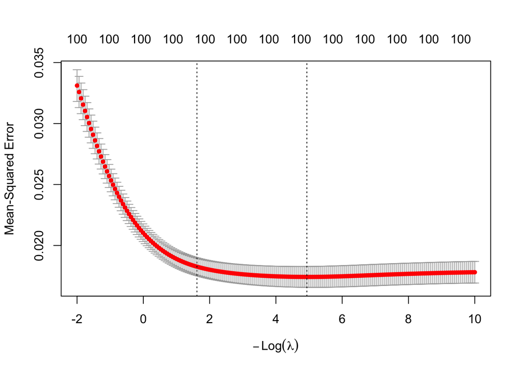

```r
set.seed(1123)

cv_ridge <- cv.glmnet(
  X_tr,
  y_tr,
  alpha = 0,
  standardize = TRUE,
  nfolds = 10,
  ## I usually don't specify lambda
  lambda = exp(seq(-10, 2, length.out = 200))
)
plot(cv_ridge)
```

```r
ridge_fit_min <- glmnet(
  X_tr,
  y_tr,
  alpha = 0,
  lambda = cv_ridge$lambda.min,
  standardize = TRUE
)

ridge_fit_1se <- glmnet(
  X_tr,
  y_tr,
  alpha = 0,
  lambda = cv_ridge$lambda.1se,
  standardize = TRUE
)
```

### 3.2.2 Lasso

Lasso (L1)

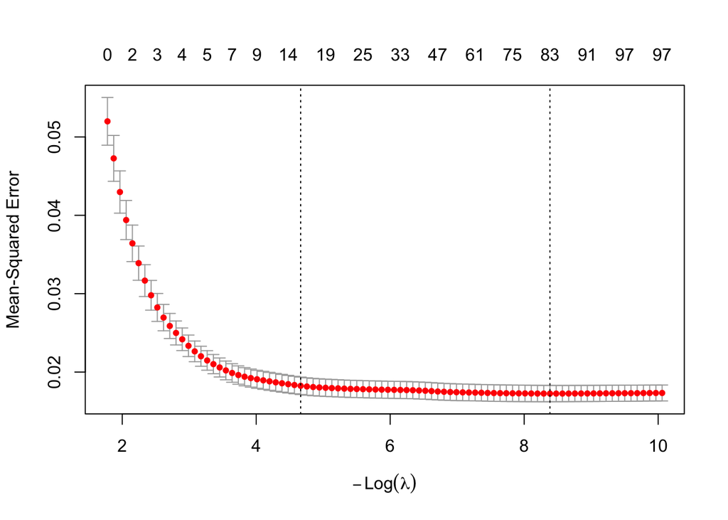

```r
set.seed(2)
cv_lasso <- cv.glmnet(  X_tr, y_tr, alpha = 1, standardize = TRUE, nfolds = 10)
plot(cv_lasso)
```

```r
lasso_min  <-  glmnet(  X_tr,y_tr, alpha = 1, lambda = cv_lasso$lambda.min,  standardize = TRUE)
lasso_1se  <-  glmnet(  X_tr,y_tr, alpha = 1, lambda = cv_lasso$lambda.1se,  standardize = TRUE)
```

## 3.3 Part C

(**10 pts**)Fit MCP and SCAD regression models. Compare variable selection patterns to the lasso. Do MCP/SCAD retain fewer predictors while maintaining predictive accuracy? Briefly explain.

SCAD and MCP

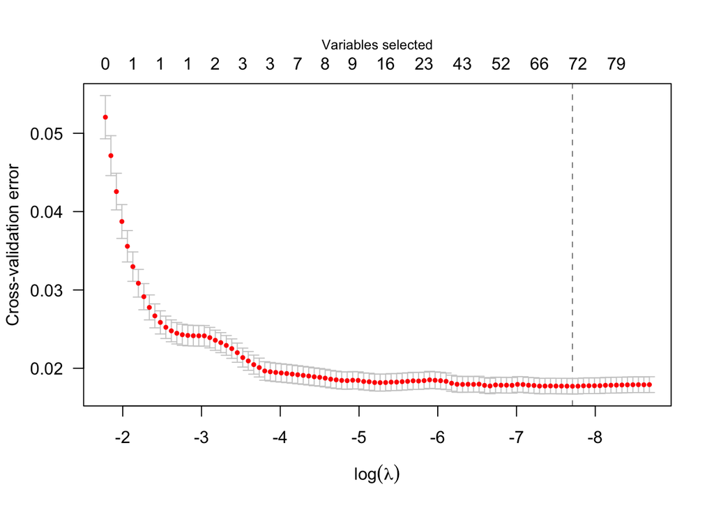

```r
set.seed(4)
cv_mcp  <- cv.ncvreg(X_tr,y_tr, penalty = "MCP",  family = "gaussian", nfolds = 10)
plot(cv_mcp)
```

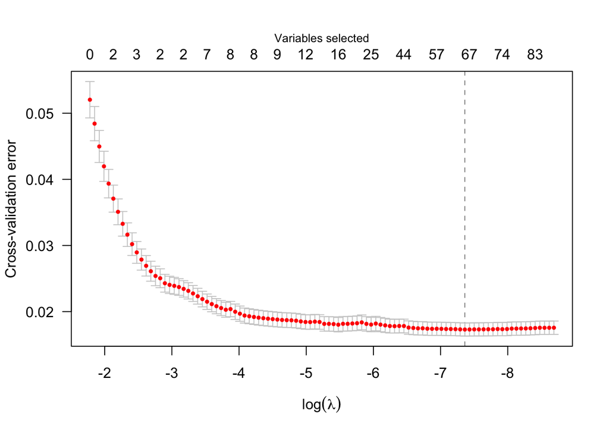

```r
lambda.min.mcp = cv_mcp$lambda.min

cv_scad <- cv.ncvreg(X_tr,y_tr, penalty = "SCAD", family = "gaussian", nfolds = 10)
plot(cv_scad)
```

```r
lambda.min.scad = cv_scad$lambda.min

mcp_fit <- cv_mcp$fit
scad_fit <- cv_scad$fit
```

### 3.3.1 Final results

Now let’s look at the test error and the number of non-zero coefficients.

```r
pred_ols <- predict(lm_model, test)
ols_rmse = rmse(y_te, pred_ols)
pred_ridge_min <- predict(ridge_fit_min, X_te)
pred_ridge_1se <- predict(ridge_fit_1se, X_te)
rmse_min = rmse(y_te, pred_ridge_min)
rmse_1se = rmse(y_te, pred_ridge_1se)
pred_lasso_min <- predict(lasso_min, X_te)
pred_lasso_1se <- predict(lasso_1se, X_te)

lasso_min_rmse <- rmse(y_te, pred_lasso_min)
lasso_1se_rmse <- rmse(y_te, pred_lasso_1se)
pred_mcp  <- predict(mcp_fit, X_te, lambda = lambda.min.mcp)
pred_scad <- predict(scad_fit, X_te, lambda = lambda.min.scad)

mcp_rmse  <- rmse(y_te, pred_mcp)
scad_rmse <- rmse(y_te, pred_scad)
coef_names <- rownames(as.matrix(coef(ridge_fit_min)))


summ <- tibble(
  Method = c("OLS","Ridge (min)","Ridge (1SE)","Lasso (min)","Lasso (1SE)","MCP","SCAD"),
  Test_RMSE = c(
    ols_rmse,
    rmse_min,
    rmse_1se,
    lasso_min_rmse,
    lasso_1se_rmse,
    mcp_rmse,
    scad_rmse
  ),
  Nonzero = c(
    sum(coef(lm_model)[-1]!=0),
    sum(coef(ridge_fit_min )[-1]!=0),
    sum(coef(ridge_fit_1se )[-1]!=0),
    sum(coef(lasso_min )[-1]!=0),
    sum(coef(lasso_1se )[-1]!=0),
    sum(mcp_fit$beta[,cv_mcp$min][-1]!=0),
    sum(scad_fit$beta[,cv_scad$min][-1]!=0)
  )
)

summ %>% kable(digits = 4, caption = "Number of non-zero coefficients.", escape = TRUE)
```

Number of non-zero coefficients.

| Method | Test_RMSE | Nonzero |
| --- | --- | --- |
| OLS | 0.1482 | 100 |
| Ridge (min) | 0.1463 | 100 |
| Ridge (1SE) | 0.1503 | 100 |
| Lasso (min) | 0.1467 | 81 |
| Lasso (1SE) | 0.1474 | 15 |
| MCP | 0.1480 | 71 |
| SCAD | 0.1476 | 67 |

Here are the variables with a non-zero effect is the lasso model with the 1 SE rule:

```r
tibble(
  Variables = coef_names[coef(lasso_1se )[,1]!=0][-1],
  Beta = coef(lasso_1se )[coef(lasso_1se )[,1]!=0,][-1]
) %>% kable(digits = 3)
```

| Variables | Beta |
| --- | --- |
| racepctblack | 0.035 |
| racePctWhite | -0.136 |
| agePct12t29 | -0.022 |
| pctUrban | 0.015 |
| MalePctDivorce | 0.102 |
| PctKids2Par | -0.270 |
| PctWorkMom | -0.029 |
| PctIlleg | 0.196 |
| PctPersDenseHous | 0.122 |
| HousVacant | 0.101 |
| PctHousOccup | -0.054 |
| PctVacantBoarded | 0.008 |
| NumInShelters | 0.000 |
| NumStreet | 0.129 |
| LemasPctOfficDrugUn | 0.017 |

I ran the above several times with different seeds for the initial creation of the training and test data. Commonly, OLS, Rigde (min) and Lasso (min) had the best RMSE with Lasso (1SE), MCP, and SCAD close behind.

Another common trend was for there to be a big gap in the number of predictors for Lasso with the min and 1SE criteria (we see that here).

For these results, I think it’s clear that the Lasso (1SE) model is the best. It uses far fewer predictors (thus, has easier interpretations) and it’s predictive ability is quite good.